# Homework #1

See all that stuff above. You should change `theme` and `highligh-style` to fit your own style. You can find them here: https://quarto.org/docs/output-formats/html-themes.html

Seriously, you should start finding your own style, so definitely change them!

## Data

You’ll be working with the following data files:

`artist_genre.txt`

`artist_name.csv`

`artist_net_worth.csv`

`artist_number_one_hits.csv`

`artist_top_hits.csv`

The only file that you are going to need to be careful about is the `artist_genre` file – be sure to look at the extension, refer to the notes on I/O, and read the help file!

### Pre-join Goals

- Use the aggregate function to ensure that each file only contains unique rows.
- If duplicates exist, handle them. You can either de-duplicate them (the `duplicate` function is helpful here) or `aggregate` them to single rows. The choice is yours and yours alone, but be sure to justify your decision.

## Goals

Read the files in and then accomplish the following goals:

- `artist_genre.txt`

```r
artist_description <- read.table("~/Downloads/artist_genre.txt", header = TRUE)

artist_description <- aggregate(genre ~ Artist, data = artist_description, FUN = unique)
```

- `artist_name.csv`

```r
artist_name <- read.csv("~/Downloads/artist_name.csv")

artist_name <- aggregate(Birth_Year ~ Artist, data = artist_name, FUN = unique)
```

- Which 5 artists have the greatest net worth?

```r
artist_net_worth <- read.csv("~/Downloads/artist_net_worth.csv")

artist_net_worth$net_worth_millions <- as.numeric(gsub("\\$", "",artist_net_worth$net_worth_millions))

artist_net_worth <- aggregate(net_worth_millions ~ Artist, artist_net_worth, FUN = unique)

artist_net_worth <- artist_net_worth[order(artist_net_worth$net_worth_millions, decreasing = TRUE),]

head(artist_net_worth, n=5)
```

```
               Artist net_worth_millions
25              Jay-Z               1500
54        The Beatles               1500
1                ABBA                900
58 The Rolling Stones                900
38            Madonna                850
```

```r
dups <- duplicated(artist_net_worth$Artist)

artist_net_worth <- artist_net_worth[dups==FALSE,]

#used as.numeric because net worth is not a factor so you need to turn it into numeric
#aggregate(net_worth_millions ~ Artist, artist_net_worth, length)
#length - takes a vector and tells you how many things are inside n
#== means to ask a question or tell it to do something
#false is the ones that are not duplicate
```

```r
artist_top_hits <- read.csv("~/Downloads/artist_top_hits.csv")

artist_top_hits <- aggregate(cbind(Top_Hit, Year) ~ Artist, data = artist_top_hits, FUN = unique)

#summary(artist_top_hits)
```

- Which 15 artists have the most number 1 hits?

```r
artist_number_one_hits <- read.csv("~/Downloads/artist_number_one_hits.csv")

dups <- duplicated(artist_number_one_hits$artist)

artist_number_one_hits <- artist_number_one_hits [dups == FALSE,]

head(artist_number_one_hits[order(artist_number_one_hits$number_one_hits, decreasing = TRUE),], n=15)
```

```
               artist number_one_hits
1         The Beatles              20
18       Mariah Carey              19
4       Elvis Presley              18
10            Rihanna              14
2     Michael Jackson              13
5             Madonna              12
15    Whitney Houston              11
23      Stevie Wonder              10
22         Katy Perry               9
16 The Rolling Stones               8
32              Drake               8
8        Taylor Swift               7
28         Bruno Mars               7
9          Elton John               6
19         Ed Sheeran               6
```

```r
#head(sort(artist_number_one_hits$number_one_hits, decreasing = TRUE))
#order(artist_number_one_hits$number_one_hits)
#I chose to use duplicated function because there are repeating artist names
```

- Which 10 artists have the fewest studio albums?

```r
artist_studio_albums <- read.csv("~/Downloads/artist_studio_albums (1).csv")
```

```r
dups <- duplicated(artist_studio_albums$Artist)

artist_studio_albums <- artist_studio_albums[dups==FALSE,]

artist_studio_albums <- artist_studio_albums[order(artist_studio_albums$studio_albums),]

head(artist_studio_albums[order(artist_studio_albums$studio_albums, decreasing = FALSE),], n=10)
```

```
                 Artist studio_albums
39        Billie Eilish             1
48                Lorde             2
55 The Notorious B.I.G.             2
12                Adele             3
28           Bruno Mars             3
31              Nirvana             3
49         Jimi Hendrix             3
54            Sam Smith             3
26       Kendrick Lamar             4
44    Justin Timberlake             4
```

```r
#artist_studio_albums
#aggregate(studio_albums ~ Artist, artist_studio_albums, length)
#order(artist_studio_albums$studio_albums)
```

```r
#artist_name
#aggregate(Birth_Year ~ Artist, artist_name, length)
#name <- aggregate(Birth_Year ~ Artist, data = artist_description, FUN = unique)
#dups <- duplicated(artist_name$Artist)
#artist_name <- artist_name[dups==FALSE,]
#order(artist_name$Birth_Year)
#tail(artist_name[order(artist_name$Birth_Year),], n=62)
```

```r
artist_data <- merge(
  x = artist_name,
  y = artist_description,
  by = 'Artist')

artist_data <- merge(
  x = artist_data,
  y= artist_net_worth,
  by = 'Artist')

artist_data <- merge(
  x = artist_data,
  y = artist_number_one_hits,
  by.x = 'Artist',
  by.y = 'artist'
)

artist_data <- merge(
  x = artist_data,
  y = artist_studio_albums,
  by = 'Artist'
)

artist_data <- merge(
  x = artist_data,
  y = artist_top_hits,
  by = 'Artist'
)

#merging data frames by common columns/row names
```

### Post-join Goals

- Create variables to capture the following ideas:
  - How long has the artist been around? You can just use their birth year.
  - Something to capture each artist’s net worth per studio album.

```r
current_year <- as.integer(format(Sys.Date(), "%Y"))

artist_data$career <- current_year - artist_data$Birth_Year

artist_data$networth_per_album <- artist_data$net_worth_millions / artist_data$studio_albums
```

- Plot net worth per studio album, the “been around” variable, and genre. There should be points and colors here.

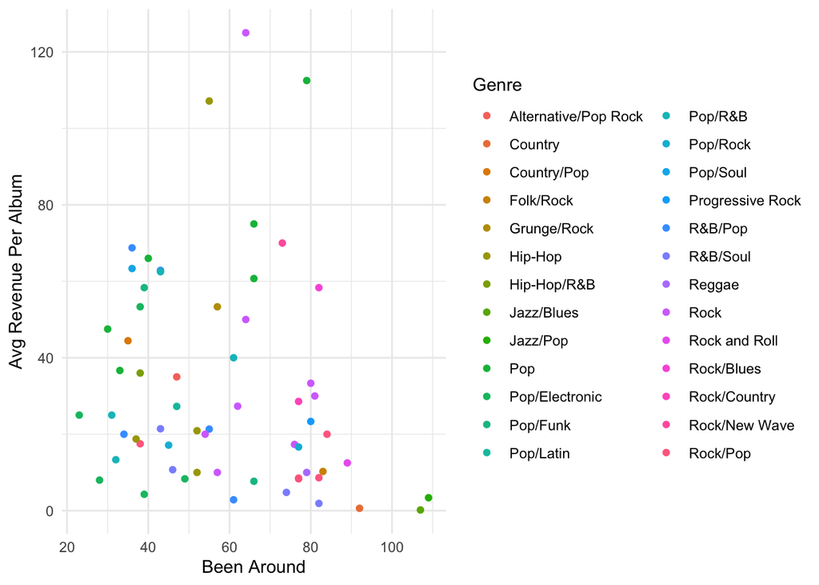

```r
library(ggplot2)

ggplot(data = artist_data,
       mapping = aes(x = career, y = networth_per_album, colour = genre)) +
  geom_point() + theme_minimal() +
  labs(x = "Been Around", y = "Avg Revenue Per Album", color = "Genre")
```

```r
#used ggplot2 because it is a system for creating graphics and I want to express the net worth per studio album, the "been around" variable, and genre colorfully
```

After you have those done, you can join your data frames together.

[output not shown]